# R Notebook

#Part I – Explore the data

```r
library(ggplot2)
```

```r
library("dplyr")
```

```r
data_small <- read.csv('C:\\Users\\praba\\Desktop\\uca1\\M1\\R programming\\exam1\\people_habits_dataset.csv')
```

```r
data_small
```

| dob | gender | height | weight | gluc | smoke | alco | active |
| --- | --- | --- | --- | --- | --- | --- | --- |
| 1974-06-28 | 1 | 163 | 111.0 | 2 | 0 | 0 | 0 |
| 1972-09-01 | 1 | 157 | 56.0 | 1 | 0 | 0 | 1 |
| 1972-10-02 | 1 | 154 | 80.0 | 1 | 0 | 0 | 1 |
| 1977-02-18 | 1 | 166 | 97.0 | 1 | 0 | 0 | 1 |
| 1964-07-17 | 1 | 157 | 62.0 | 1 | 0 | 0 | 1 |
| 1982-05-09 | 2 | 169 | 92.0 | 3 | 0 | 0 | 0 |
| 1972-03-26 | 2 | 176 | 80.0 | 1 | 0 | 0 | 0 |
| 1985-10-14 | 2 | 170 | 68.0 | 1 | 1 | 0 | 1 |
| 1978-08-15 | 2 | 178 | 103.0 | 1 | 0 | 0 | 1 |
| 1971-10-18 | 2 | 162 | 64.0 | 1 | 0 | 0 | 1 |

[output cut: 990 more lines]

##1.What are the dimensions of the data?

```r
dim(data_small)
```

```
[1] 1223    8
```

##2.What are the types of columns? What is the difference between a string and a factor? Show descriptive statistics of the data.

If x is a string it can take any value. If x is a factor it can only take a values from a list of all levels. That makes these variables more memory effecient as well.

```r
str(data_small)
```

```
'data.frame':   1223 obs. of  8 variables:
 $ dob   : chr  "1974-06-28" "1972-09-01" "1972-10-02" "1977-02-18" ...
 $ gender: int  1 1 1 1 1 2 2 2 2 2 ...
 $ height: int  163 157 154 166 157 169 176 170 178 162 ...
 $ weight: num  111 56 80 97 62 92 80 68 103 64 ...
 $ gluc  : int  2 1 1 1 1 3 1 1 1 1 ...
 $ smoke : int  0 0 0 0 0 0 0 1 0 0 ...
 $ alco  : int  0 0 0 0 0 0 0 0 0 0 ...
 $ active: int  0 1 1 1 1 0 0 1 1 1 ...
```

```r
summary(data_small)
```

```
     dob                gender          height          weight            gluc
 Length:1223        Min.   :1.000   Min.   :109.0   Min.   : 42.00   Min.   :1.000
 Class :character   1st Qu.:1.000   1st Qu.:159.0   1st Qu.: 65.00   1st Qu.:1.000
 Mode  :character   Median :1.000   Median :165.0   Median : 73.00   Median :1.000
                    Mean   :1.375   Mean   :164.6   Mean   : 74.77   Mean   :1.231
                    3rd Qu.:2.000   3rd Qu.:170.0   3rd Qu.: 83.00   3rd Qu.:1.000
                    Max.   :2.000   Max.   :250.0   Max.   :152.00   Max.   :3.000
     smoke              alco             active
 Min.   :0.00000   Min.   :0.00000   Min.   :0.0000
 1st Qu.:0.00000   1st Qu.:0.00000   1st Qu.:1.0000
 Median :0.00000   Median :0.00000   Median :1.0000
 Mean   :0.08504   Mean   :0.04906   Mean   :0.8119
 3rd Qu.:0.00000   3rd Qu.:0.00000   3rd Qu.:1.0000
 Max.   :1.00000   Max.   :1.00000   Max.   :1.0000
```

##3.Is there any NA?

```r
which(is.na(data_small))
```

```
integer(0)
```

```r
print ("Row and Col positions of NA values")
```

```
[1] "Row and Col positions of NA values"
```

```r
which(is.na(data_small), arr.ind=TRUE)
```

```
     row col
```

#Part II – Data transformation

##4.Create a new variable called age from the variable dob to obtain the age of individuals based on their date of birth. (Hint: you can use the function year() from lubridate package to get the year of the date of birth).

```r
install.packages("lubridate")
```

```
Error in install.packages : Updating loaded packages
```

```r
library(lubridate)
```

```r
choices = lubridate::year(Sys.Date())
data_small_1<- data_small %>% mutate(data_small, age= (choices-year(data_small$dob) ))
data_small_1
```

| dob | gender | height | weight | gluc | smoke | alco | active | age |
| --- | --- | --- | --- | --- | --- | --- | --- | --- |
| 1974-06-28 | 1 | 163 | 111.0 | 2 | 0 | 0 | 0 | 49 |
| 1972-09-01 | 1 | 157 | 56.0 | 1 | 0 | 0 | 1 | 51 |
| 1972-10-02 | 1 | 154 | 80.0 | 1 | 0 | 0 | 1 | 51 |
| 1977-02-18 | 1 | 166 | 97.0 | 1 | 0 | 0 | 1 | 46 |
| 1964-07-17 | 1 | 157 | 62.0 | 1 | 0 | 0 | 1 | 59 |
| 1982-05-09 | 2 | 169 | 92.0 | 3 | 0 | 0 | 0 | 41 |
| 1972-03-26 | 2 | 176 | 80.0 | 1 | 0 | 0 | 0 | 51 |
| 1985-10-14 | 2 | 170 | 68.0 | 1 | 1 | 0 | 1 | 38 |
| 1978-08-15 | 2 | 178 | 103.0 | 1 | 0 | 0 | 1 | 45 |
| 1971-10-18 | 2 | 162 | 64.0 | 1 | 0 | 0 | 1 | 52 |

[output cut: 990 more lines]

```r
NA
```

##5.Calculate the body mass index (BMI) for each of our patients using the formula BMI=Weight/(Height)2, where the weight is measured in kilograms and the height is in meters

```r
bmi <- function(weight, height) {
height/100 -> height
height^2 -> height
return(weight/height)
}
bmi_result <- bmi(data_small$weight, data_small$height)
bmi_result
```

```
   [1] 41.77801 22.71897 33.73250 35.20105 25.15315 32.21176 25.82645 23.52941 32.50852 24.38653
  [11] 22.53061 42.16563 31.97501 22.22906 38.75433 19.23356 24.22145 29.75779 19.00391 26.92744
  [21] 29.86496 24.16716 34.15416 24.44728 20.14797 25.51020 47.26562 27.39800 22.58955 27.74475
  [31] 13.76000 20.47827 28.98201 23.18339 27.13141 23.43750 35.45645 27.47138 24.12879 25.80645
  [41] 28.44095 26.29758 24.53512 24.53896 25.71166 32.44997 27.37966 28.69898 24.80159 28.25699
  [51] 25.96454 20.68515 36.43664 28.36035 29.72108 24.03461 27.77778 29.37240 23.45092 29.64269
  [61] 26.02617 36.98225 25.30693 23.52941 30.42720 28.72679 23.14050 35.83419 17.26354 27.77671
  [71] 25.39022 25.05931 29.09428 25.95156 31.69907 23.87543 45.70312 29.99671 28.13366 33.79247
  [81] 36.68410 26.21641 29.05329 21.46915 24.22145 23.52941 23.04687 33.70504 26.29849 23.52941
  [91] 24.03461 30.71834 19.10009 37.46098 20.44914 37.32403 22.31328 39.30211 30.10381 21.04805
 [101] 21.46194 28.44095 35.43667 26.92744 24.53896 27.28175 22.30936 28.95900 22.20408 30.58581
 [111] 23.12062 22.65625 25.71166 35.15625 27.94214 28.08626 25.47666 26.21882 23.33547 26.70940
 [121] 27.00513 26.02758 18.51852 23.30905 23.63403 41.45408 22.30815 26.23457 19.59184 31.55366
 [131] 24.22145 26.29849 24.53512 28.19428 24.62296 20.95727 24.69041 30.11600 25.71101 26.33289
 [141] 22.15102 24.16327 22.75831 31.23859 27.01686 37.46556 19.03114 21.36752 22.23099 34.29355
```

[output cut: 86 more lines]

#6.Create a new variable to indicate which individuals are overweight, i.e. those with a BMI over 25.

```r
data_small_1['bmi_result_f']=bmi_result
data_small_1 %>% filter(bmi_result_f>25)
```

| dob | gender | height | weight | gluc | smoke | alco | active | age | bmi_result_f |
| --- | --- | --- | --- | --- | --- | --- | --- | --- | --- |
| 1974-06-28 | 1 | 163 | 111.0 | 2 | 0 | 0 | 0 | 49 | 41.77801 |
| 1972-10-02 | 1 | 154 | 80.0 | 1 | 0 | 0 | 1 | 51 | 33.73250 |
| 1977-02-18 | 1 | 166 | 97.0 | 1 | 0 | 0 | 1 | 46 | 35.20105 |
| 1964-07-17 | 1 | 157 | 62.0 | 1 | 0 | 0 | 1 | 59 | 25.15315 |
| 1982-05-09 | 2 | 169 | 92.0 | 3 | 0 | 0 | 0 | 41 | 32.21176 |
| 1972-03-26 | 2 | 176 | 80.0 | 1 | 0 | 0 | 0 | 51 | 25.82645 |
| 1978-08-15 | 2 | 178 | 103.0 | 1 | 0 | 0 | 1 | 45 | 32.50852 |
| 1962-02-28 | 1 | 154 | 100.0 | 1 | 0 | 0 | 1 | 61 | 42.16563 |
| 1965-12-30 | 1 | 164 | 86.0 | 1 | 0 | 1 | 1 | 58 | 31.97501 |
| 1967-04-13 | 2 | 170 | 112.0 | 1 | 0 | 0 | 1 | 56 | 38.75433 |

[output cut: 753 more lines]

```r
NA
```

```r
data_small_1<- data_small_1 %>% mutate(overweight = if_else(bmi_result_f>25, 1, 0 ) )
data_small_1
```

[output not shown]

[output cut: 990 more lines]

```r
NA
NA
```

##7.Some variables are treated as integers when they should be categorical variables. Change them into factors.

```r
data_small$dob <- as.factor(data_small$dob)
data_small
```

| dob | gender | height | weight | gluc | smoke | alco | active |
| --- | --- | --- | --- | --- | --- | --- | --- |
| 1974-06-28 | 1 | 163 | 111.0 | 2 | 0 | 0 | 0 |
| 1972-09-01 | 1 | 157 | 56.0 | 1 | 0 | 0 | 1 |
| 1972-10-02 | 1 | 154 | 80.0 | 1 | 0 | 0 | 1 |
| 1977-02-18 | 1 | 166 | 97.0 | 1 | 0 | 0 | 1 |
| 1964-07-17 | 1 | 157 | 62.0 | 1 | 0 | 0 | 1 |
| 1982-05-09 | 2 | 169 | 92.0 | 3 | 0 | 0 | 0 |
| 1972-03-26 | 2 | 176 | 80.0 | 1 | 0 | 0 | 0 |
| 1985-10-14 | 2 | 170 | 68.0 | 1 | 1 | 0 | 1 |
| 1978-08-15 | 2 | 178 | 103.0 | 1 | 0 | 0 | 1 |
| 1971-10-18 | 2 | 162 | 64.0 | 1 | 0 | 0 | 1 |

[output cut: 990 more lines]

8.Change levels of the gender variable, replacing 1 and 2 with female and male.

```r
data_small_1$gender <- cut(data_small_1$gender, 2, labels=c('female','male'))
data_small_1
```

| dob | gender | height | weight | gluc | smoke | alco | active | age | bmi_result_f |
| --- | --- | --- | --- | --- | --- | --- | --- | --- | --- |
| 1974-06-28 | female | 163 | 111.0 | 2 | 0 | 0 | 0 | 49 | 41.77801 |
| 1972-09-01 | female | 157 | 56.0 | 1 | 0 | 0 | 1 | 51 | 22.71897 |
| 1972-10-02 | female | 154 | 80.0 | 1 | 0 | 0 | 1 | 51 | 33.73250 |
| 1977-02-18 | female | 166 | 97.0 | 1 | 0 | 0 | 1 | 46 | 35.20105 |
| 1964-07-17 | female | 157 | 62.0 | 1 | 0 | 0 | 1 | 59 | 25.15315 |
| 1982-05-09 | male | 169 | 92.0 | 3 | 0 | 0 | 0 | 41 | 32.21176 |
| 1972-03-26 | male | 176 | 80.0 | 1 | 0 | 0 | 0 | 51 | 25.82645 |
| 1985-10-14 | male | 170 | 68.0 | 1 | 1 | 0 | 1 | 38 | 23.52941 |
| 1978-08-15 | male | 178 | 103.0 | 1 | 0 | 0 | 1 | 45 | 32.50852 |
| 1971-10-18 | male | 162 | 64.0 | 1 | 0 | 0 | 1 | 52 | 24.38653 |

[output cut: 990 more lines]

```r
data_small %>% group_by(gender,gluc)%>%summarise(avg_weight = mean(weight),sd_weight = sd(weight))
```

| gender | gluc | avg_weight | sd_weight |
| --- | --- | --- | --- |
| 1 | 1 | 71.94507 | 13.77044 |
| 1 | 2 | 79.00000 | 17.75090 |
| 1 | 3 | 80.39437 | 18.79322 |
| 2 | 1 | 76.60274 | 13.36221 |
| 2 | 2 | 83.56667 | 13.16653 |
| 2 | 3 | 81.32143 | 15.66088 |

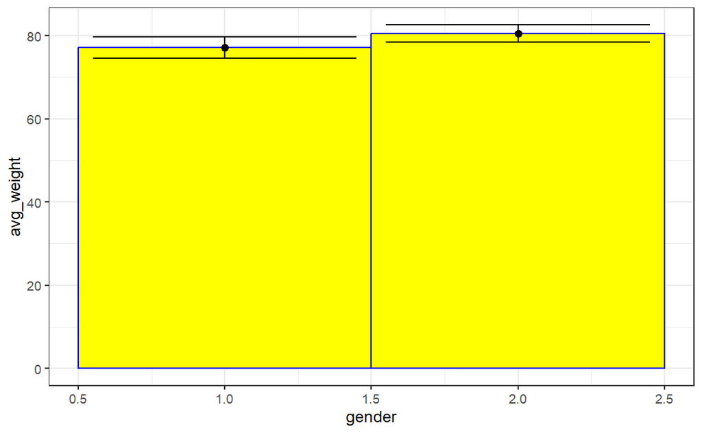

```r
data_small %>% group_by(gender,gluc)%>%summarise(avg_weight = mean(weight),sd_weight = sd(weight))%>%  ggplot(aes(x=gender,y=avg_weight)) + geom_bar(stat="summary" ,col="blue2",fill="yellow",width=1)+stat_summary(fun = mean)+stat_summary(geom="errorbar")
```

#Part III – Plotting (5 points)

##10.Plot a jitter plot of the weight of individuals for both categories of active.

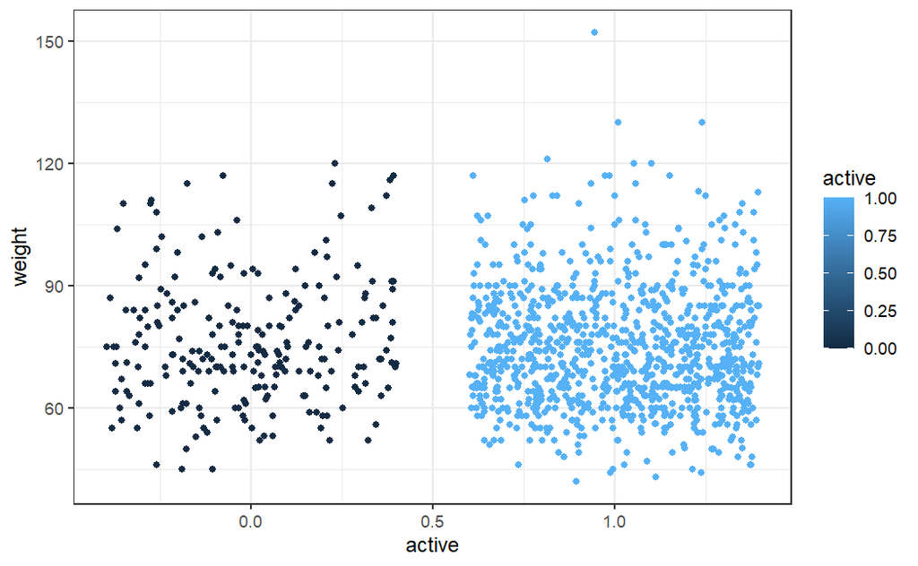

```r
data_small %>% ggplot(aes(x = active, y = weight))+ geom_jitter(aes(col =active),show.legend = TRUE)
install.packages("lubridate")
```

```r
data_small
```

| dob | gender | height | weight | gluc | smoke | alco | active |
| --- | --- | --- | --- | --- | --- | --- | --- |
| 1974-06-28 | 1 | 163 | 111.0 | 2 | 0 | 0 | 0 |
| 1972-09-01 | 1 | 157 | 56.0 | 1 | 0 | 0 | 1 |
| 1972-10-02 | 1 | 154 | 80.0 | 1 | 0 | 0 | 1 |
| 1977-02-18 | 1 | 166 | 97.0 | 1 | 0 | 0 | 1 |
| 1964-07-17 | 1 | 157 | 62.0 | 1 | 0 | 0 | 1 |
| 1982-05-09 | 2 | 169 | 92.0 | 3 | 0 | 0 | 0 |
| 1972-03-26 | 2 | 176 | 80.0 | 1 | 0 | 0 | 0 |
| 1985-10-14 | 2 | 170 | 68.0 | 1 | 1 | 0 | 1 |
| 1978-08-15 | 2 | 178 | 103.0 | 1 | 0 | 0 | 1 |
| 1971-10-18 | 2 | 162 | 64.0 | 1 | 0 | 0 | 1 |

[output cut: 990 more lines]

```r
data_small%>% group_by(gluc) %>% summarise(count_m_f=(n=n()))
```

| gluc | count_m_f |
| --- | --- |
| 1 | 1040 |
| 2 | 84 |
| 3 | 99 |

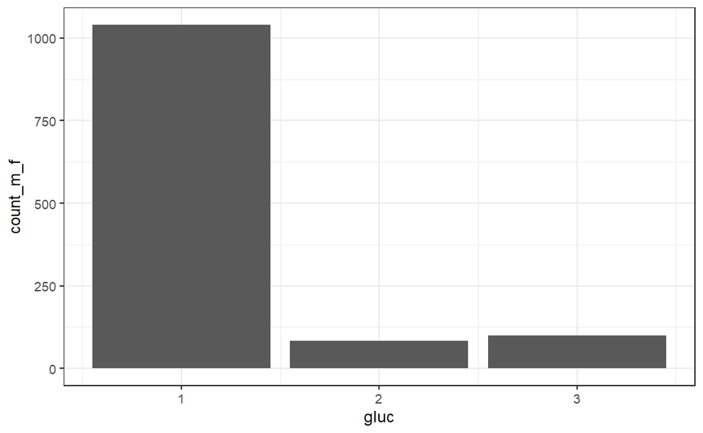

```r
data_small%>% group_by(gluc) %>% summarise(count_m_f=(n=n()))%>%ggplot(aes(x=gluc,y=count_m_f))+
  geom_bar(stat = "identity")
```

12.Plot out a boxplot of age for both categories of alco.

```r
data_small_1
```

| dob | gender | height | weight | gluc | smoke | alco | active | age | bmi_result_f |
| --- | --- | --- | --- | --- | --- | --- | --- | --- | --- |
| 1974-06-28 | female | 163 | 111.0 | 2 | 0 | 0 | 0 | 49 | 41.77801 |
| 1972-09-01 | female | 157 | 56.0 | 1 | 0 | 0 | 1 | 51 | 22.71897 |
| 1972-10-02 | female | 154 | 80.0 | 1 | 0 | 0 | 1 | 51 | 33.73250 |
| 1977-02-18 | female | 166 | 97.0 | 1 | 0 | 0 | 1 | 46 | 35.20105 |
| 1964-07-17 | female | 157 | 62.0 | 1 | 0 | 0 | 1 | 59 | 25.15315 |
| 1982-05-09 | male | 169 | 92.0 | 3 | 0 | 0 | 0 | 41 | 32.21176 |
| 1972-03-26 | male | 176 | 80.0 | 1 | 0 | 0 | 0 | 51 | 25.82645 |
| 1985-10-14 | male | 170 | 68.0 | 1 | 1 | 0 | 1 | 38 | 23.52941 |
| 1978-08-15 | male | 178 | 103.0 | 1 | 0 | 0 | 1 | 45 | 32.50852 |
| 1971-10-18 | male | 162 | 64.0 | 1 | 0 | 0 | 1 | 52 | 24.38653 |

[output cut: 990 more lines]

```r
library(patchwork)
library(gridExtra)
library(ggplot2)
library("dplyr")
```

```r
data_small_1$alco <- as.factor(data_small_1$alco)
data_small_1
```

| dob | gender | height | weight | gluc | smoke | alco | active | age | bmi_result_f |
| --- | --- | --- | --- | --- | --- | --- | --- | --- | --- |
| 1974-06-28 | female | 163 | 111.0 | 2 | 0 | 0 | 0 | 49 | 41.77801 |
| 1972-09-01 | female | 157 | 56.0 | 1 | 0 | 0 | 1 | 51 | 22.71897 |
| 1972-10-02 | female | 154 | 80.0 | 1 | 0 | 0 | 1 | 51 | 33.73250 |
| 1977-02-18 | female | 166 | 97.0 | 1 | 0 | 0 | 1 | 46 | 35.20105 |
| 1964-07-17 | female | 157 | 62.0 | 1 | 0 | 0 | 1 | 59 | 25.15315 |
| 1982-05-09 | male | 169 | 92.0 | 3 | 0 | 0 | 0 | 41 | 32.21176 |
| 1972-03-26 | male | 176 | 80.0 | 1 | 0 | 0 | 0 | 51 | 25.82645 |
| 1985-10-14 | male | 170 | 68.0 | 1 | 1 | 0 | 1 | 38 | 23.52941 |
| 1978-08-15 | male | 178 | 103.0 | 1 | 0 | 0 | 1 | 45 | 32.50852 |
| 1971-10-18 | male | 162 | 64.0 | 1 | 0 | 0 | 1 | 52 | 24.38653 |

[output cut: 990 more lines]

```r
# data_small
```

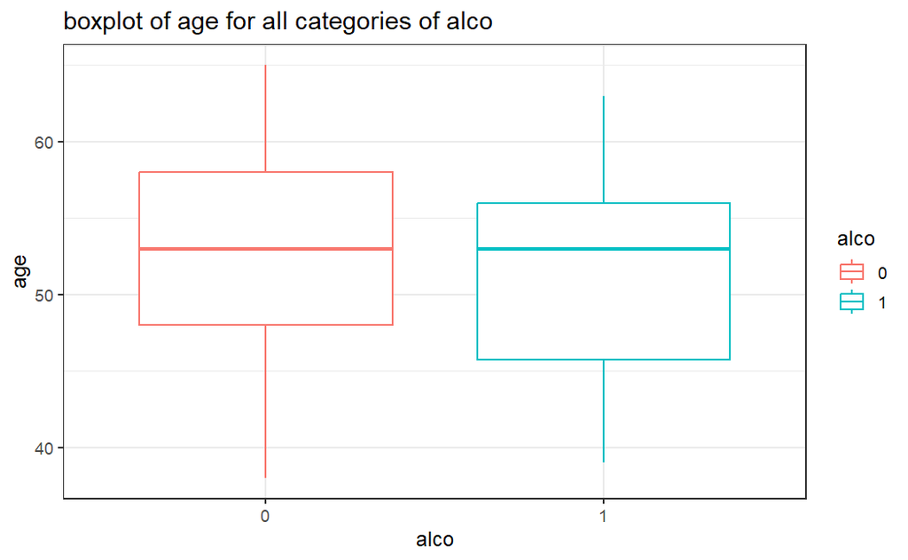

```r
data_small_1 %>% ggplot(aes(x=alco,y=age))+geom_boxplot(aes(col=alco))+
  ggtitle("boxplot of age for all categories of alco")
```

#13.Plot out a violin plot of the BMI for both males and females.

```r
data_small_1
```

| dob | gender | height | weight | gluc | smoke | alco | active | age | bmi_result_f |
| --- | --- | --- | --- | --- | --- | --- | --- | --- | --- |
| 1974-06-28 | female | 163 | 111.0 | 2 | 0 | 0 | 0 | 49 | 41.77801 |
| 1972-09-01 | female | 157 | 56.0 | 1 | 0 | 0 | 1 | 51 | 22.71897 |
| 1972-10-02 | female | 154 | 80.0 | 1 | 0 | 0 | 1 | 51 | 33.73250 |
| 1977-02-18 | female | 166 | 97.0 | 1 | 0 | 0 | 1 | 46 | 35.20105 |
| 1964-07-17 | female | 157 | 62.0 | 1 | 0 | 0 | 1 | 59 | 25.15315 |
| 1982-05-09 | male | 169 | 92.0 | 3 | 0 | 0 | 0 | 41 | 32.21176 |
| 1972-03-26 | male | 176 | 80.0 | 1 | 0 | 0 | 0 | 51 | 25.82645 |
| 1985-10-14 | male | 170 | 68.0 | 1 | 1 | 0 | 1 | 38 | 23.52941 |
| 1978-08-15 | male | 178 | 103.0 | 1 | 0 | 0 | 1 | 45 | 32.50852 |
| 1971-10-18 | male | 162 | 64.0 | 1 | 0 | 0 | 1 | 52 | 24.38653 |

[output cut: 990 more lines]

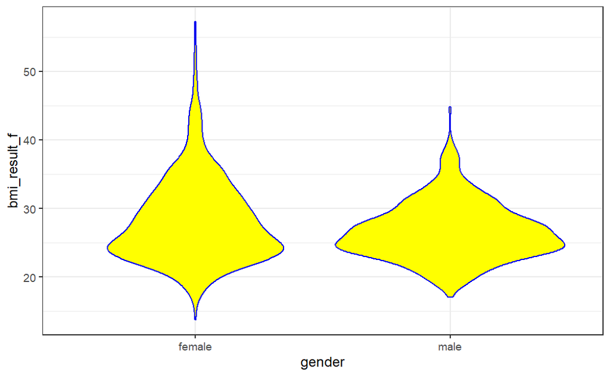

```r
theme_set(theme_bw(base_size=12))
data_small_1 %>% ggplot(aes(y = bmi_result_f, x = gender),) + geom_violin(col="blue2",fill="yellow")
```

#Part IV – Selecting columns (3 point)

##14.Select the columns 1 and 4.

```r
data_small[c(1,4)]
```

| dob | weight |
| --- | --- |
| 1974-06-28 | 111.0 |
| 1972-09-01 | 56.0 |
| 1972-10-02 | 80.0 |
| 1977-02-18 | 97.0 |
| 1964-07-17 | 62.0 |
| 1982-05-09 | 92.0 |
| 1972-03-26 | 80.0 |
| 1985-10-14 | 68.0 |
| 1978-08-15 | 103.0 |
| 1971-10-18 | 64.0 |

[output cut: 990 more lines]

15.Select all the columns ending with the letter “e”.

```r
data_small %>% select(ends_with('e'))
```

| smoke | active |
| --- | --- |
| 0 | 0 |
| 0 | 1 |
| 0 | 1 |
| 0 | 1 |
| 0 | 1 |
| 0 | 0 |
| 0 | 0 |
| 1 | 1 |
| 0 | 1 |
| 0 | 1 |

[output cut: 990 more lines]

```r
NA
```

16.Select all the columns except smoke.

```r
data_small %>% select(-smoke)
```

| dob | gender | height | weight | gluc | alco | active |
| --- | --- | --- | --- | --- | --- | --- |
| 1974-06-28 | 1 | 163 | 111.0 | 2 | 0 | 0 |
| 1972-09-01 | 1 | 157 | 56.0 | 1 | 0 | 1 |
| 1972-10-02 | 1 | 154 | 80.0 | 1 | 0 | 1 |
| 1977-02-18 | 1 | 166 | 97.0 | 1 | 0 | 1 |
| 1964-07-17 | 1 | 157 | 62.0 | 1 | 0 | 1 |
| 1982-05-09 | 2 | 169 | 92.0 | 3 | 0 | 0 |
| 1972-03-26 | 2 | 176 | 80.0 | 1 | 0 | 0 |
| 1985-10-14 | 2 | 170 | 68.0 | 1 | 0 | 1 |
| 1978-08-15 | 2 | 178 | 103.0 | 1 | 0 | 1 |
| 1971-10-18 | 2 | 162 | 64.0 | 1 | 0 | 1 |

[output cut: 990 more lines]

```r
NA
```

#Part V – Filtering rows (4 point)

```r
library(dplyr)
```

```r
data_small_1 %>% filter(age>65 & gender=='male' )
```

| dob | gender | height | weight | gluc | smoke | alco | active | age | bmi_result_f |
| --- | --- | --- | --- | --- | --- | --- | --- | --- | --- |

##18.Filter the rows for alcoholics or smokers.

```r
data_small_1 %>% filter(alco==1 | smoke==1)
```

| dob | gender | height | weight | gluc | smoke | alco | active | age | bmi_result_f |
| --- | --- | --- | --- | --- | --- | --- | --- | --- | --- |
| 1985-10-14 | male | 170 | 68.0 | 1 | 1 | 0 | 1 | 38 | 23.52941 |
| 1965-12-30 | female | 164 | 86.0 | 1 | 0 | 1 | 1 | 58 | 31.97501 |
| 1976-03-30 | male | 174 | 62.0 | 1 | 1 | 0 | 1 | 47 | 20.47827 |
| 1966-07-29 | male | 176 | 76.0 | 1 | 1 | 1 | 1 | 57 | 24.53512 |
| 1966-08-09 | female | 165 | 70.0 | 1 | 1 | 1 | 0 | 57 | 25.71166 |
| 1982-02-06 | male | 168 | 70.0 | 1 | 1 | 0 | 1 | 41 | 24.80159 |
| 1967-02-03 | male | 169 | 81.0 | 1 | 1 | 1 | 0 | 56 | 28.36035 |
| 1964-05-08 | male | 162 | 78.0 | 1 | 1 | 0 | 1 | 59 | 29.72108 |
| 1978-09-19 | male | 180 | 90.0 | 1 | 1 | 1 | 1 | 45 | 27.77778 |
| 1968-05-17 | male | 174 | 71.0 | 1 | 1 | 0 | 1 | 55 | 23.45092 |

[output cut: 127 more lines]

19.How many people smoke, drink and are active?

```r
nrow(data_small_1%>% filter(smoke ==1 & alco==1 & active==1))
```

```
[1] 21
```

```r
data_small_1["overweight"]
```

| overweight |
| --- |
| 1 |
| 0 |
| 1 |
| 1 |
| 1 |
| 1 |
| 1 |
| 0 |
| 1 |
| 0 |

[output cut: 990 more lines]